# OpenStreetMap project

## Data Wrangling with MongoDB

### by Iulia Khomenko

Map area: Lviv region, Ukraine

### 1. Problems encountered in the map

This project involves auditing and cleaning three map fields: postal codes, street names and housenumbers. There are several common problems for these fields :

1) Cyrillic characters: almost all values inserted in the map by users are written in Ukrainian with Cyrillic characters, which makes it a bit more challenging to display, search and match them in Python than English text. We need to constantly monitor what type of data is produced at each stage of the program and keep it consistent throughout the whole project. Since OSM xml files are unicode encoded, this project is designed to maintain unicode encoding for all the input and output data.

#### To handle Cyrillic characters properly in Python it is necessary to:

- add an encoding header `# -*- coding: utf-8 -*-` at the top of the script, that will tell python which encoding will be used in the script;
- explicitly specify unicode encoding when creating new variables (strings) that involve Cyrillic letters, otherwise they will be automatically created with `'str'` type and represented in bytes. This could be done in two ways : 1) adding letter 'u' before the string 2) using python unicode() function

E.g.:

```python
#without explicitly specifying the unicode encoding
test_string = 'привет'
print type(test_string)

#stating unicode encoding adding 'u' letter
test_string = u'привет'
print type(test_string)

#stating unicode encoding using unicode() function in Python
test_string = unicode('привет', 'utf-8')
print type(test_string)
```

```
<type 'str'>
<type 'unicode'>
<type 'unicode'>
```

- while using regex to search or match Cyrillic characters, the unicode encoding should be specified in `flags` parameter. In case Cyrillic letters are used inside regex pattern (e.g. specifying characters range), the encoding should also be indicated by placing letter 'u' before the begining of the pattern: e.g. `re.match(ur'^\d+(\-\d+)?[а-я]?(\/\d+)?$',housenumber,re.UNICODE)`

However, Cyrillic characters still keep unicode represenation when in Python container (dictionary or list), so in order to read the information, all elements inside the container should be printed one by one.

2) Missing information: the streetnames field was partially missing street types, so we had to reach out for external sources to restore the missing data. Since such data is not avilable in ready-to-download format, we had to scrape it online, compile a list of street names with correct street types and match problematic data points against this list. The challenging part was the scraping process as we had to loop through 12 web-pages to get the complete data:

- first we needed to understand the url structure, so we can reproduce it in our code and make correct requests to switch the webpages. Since we had to make multiple requests it was also important not to overload the server of the website we are scraping from. To avoid this we had to control the crawling speed, so we used sleep() function in Python, that suspended our programm after each request for random number of seconds before it makes the next request, we also used randint() function to generate the random number of seconds that the programm had to wait. By crawling the webpages in this way, the program is sort of copying human behaviour and makes less pressure on webserver;
- secondly we had to understand the html structure of pages we scrape from, to get the correct data. Since all the pages are similar, it made sense just to learn the structure of one page to be able to work with the others. We used BeautifulSoup to parse html contents and get the necessary information;
- lastly, we had to figure out how to store the scraped information: we did scraping directly from the webpages since it would take too much resources to save all 12 pages locally. Including our web-scraping function directly into our project so it will run together with the rest of the code every time, was not an option because the scraping process is taking around 190 sec, so it will slow down the performance of the whole code significantly. So we made our web-scraping function to write all scraped information into the local csv file, so the project streetnames auditing and cleaning functions just had to extract the list from the local csv file instead of do crawling and scraping over and over again.

3) Inconsistant formating : this was the common problem for both streetnames and housenumbers fields. For housenumbers it was inconsistant capitalization of letters (e.g. the standard way of writting a housenumber is '158a', while it could have been written as '158A', '158 a' or '158-A' and so on.), messy way of writting the building number after the housenumber (e.g. the standard housenumber '47c building 7' could have been written as '47c build.7' or '47c b7' and so on).

For streetnames is was inconsistant way of writting street types (e.g. street type comes before the street name), mixing Latin letters with Cyrillic (while the biggest part of dataset information is written in Cyrillic, there were some streetnames written with Latin letters), inconsistancy in writting street names(some street names start with lowercase letter or some street names are written in different manner, e.g. 'Franko I. Street' could be written as 'Franko Ivan Street' or 'I. Franko Street' and so on)

#### To deal with formatting inconsistancy programmatically, we used:

- regular expressions to detect all possible ways of incorrect writting of a housenumber and make it standard;
- mapping to detect the incorrect way of writting a building number and correct it properly (we created a list of all possible ways of writting a building number and if a street name include any of the elements from such list we corrected it)
- to convert Latin letters into Cyrillic we used `translit()` function from Python `transliterate` library, to detect the Latin text we used re.search with Latincharacter range pattern ( `re.searh(r'[a-zA-Z]', string)`)

4) Outdated and incorrect information. This was the problem for postal codes. To detect the incorrect information we used regular expressions (typical postal code for Lviv region is a 5-digit number, starting with :79,80,81 or 82, so we could easily filter out the postal codes outside Lviv region area). Using regular expressions, we also detected invalid postcodes (those with less than 5-digits and/or problematic characters).

To check if there are any potential problems with valid postal codes (i.e. those with 5-digits, starting with 79,80,81 or 82), we matched them against the 'golden standard' - a list of postcodes for Lviv region provided by Ukrainian National Postal Service(UNPS), which we scraped from UNPS website by downloading the webpage, using BeautifulSoup library to parse the local html content and extract necessary information. While matching our postal codes against the the scraped list, we noticed several postcodes that were missing from the 'golden standard'. After some googling we discovered those postal codes are valid but outdated (they were removed by UNPS).

At the cleaning stage we removed the postal codes that were incorrect or invalid, while the outdated postal codes we decided to keep without changes since they are still valid.

### 2. Overview of the data

Calculating the size of both OSM XML and JSON files :

```python
import os
bytes_xml=os.path.getsize("/Users/iulia/Documents/Docs/StudyMaterials/Udacity/DAND/P3/OSM_Lviv.osm")
bytes_json=os.path.getsize("/Users/iulia/Documents/Docs/StudyMaterials/Udacity/DAND/P3/OSM_Lviv.osm.json")

#small function that take number of bytes and converts to diesired unit
def bytesto(bytes, to, bsize=1024):
    a = {'k' : 1, 'm': 2, 'g' : 3, 't' : 4, 'p' : 5, 'e' : 6 }
    r = float(bytes)
    for i in range(a[to]):
        r = r / bsize
    return(r)
print 'Size of OSM XML file:', "{0:.2f}".format(bytesto(bytes_xml,'m')), 'MB'
print 'Size of JSON file:', "{0:.2f}".format(bytesto(bytes_json,'m')), 'MB'
```

```
Size of OSM XML file: 79.09 MB
Size of JSON file: 113.86 MB
```

#### Basic statistical overview of the dataset:

```python
# -*- coding: utf-8 -*-
#function that creates MongoDB client instance
from pymongo import MongoClient
import pprint

client = MongoClient('mongodb://localhost:27017')
db = client['osm_project']
```

```python
print 'Number of documents in Lviv collection:', db.lviv.count()
print 'Number of nodes:', db.lviv.find({'type':'node'}).count()
print 'Number of ways:', db.lviv.find({'type':'way'}).count()
print 'Number of unique contributing users:', len(db.lviv.distinct('created.uid'))
```

```
Number of documents in Lviv collection: 406557
Number of nodes: 344683
Number of ways: 59873
Number of unique contributing users: 800
```

Let' see the top 10 contributors for Lviv area

```python
pipeline=[{'$group':{'_id':'$created.user','contributions':{'$sum':1}}},{'$sort':{'contributions': -1}},{'$limit': 10}]
print 'Top 10 contributing users:'
for i in db.lviv.aggregate(pipeline):
     print i.values()[0],':', i.values()[1]
```

```
Top 10 contributing users:
ikovaltaras : 89587
Сергій Дубик : 70629
DimaZ : 34419
Zcor : 32957
ihorb : 30519
marcis60 : 24519
VARVAR8 : 13644
Svitozar : 12511
keepcalmandmapon : 9098
alex___ : 6583
```

Now we can check what ratio from total number of contributions is made by each of the top 10 contributors

```python
totalContributionsCount = db.lviv.count()
pipeline=[{'$group':{'_id':'$created.user','contributions':{'$sum':1}}},
          {'$sort':{'contributions': -1}},
          {'$limit': 10},
         {'$project': {'ratio': {'$divide':['$contributions',totalContributionsCount]}}}]
print 'Top 10 contributing users:'
for i in db.lviv.aggregate(pipeline):
     print i.values()[0],':', "{0:.2f}".format(i.values()[1])
```

```
Top 10 contributing users:
ikovaltaras : 0.22
Сергій Дубик : 0.17
DimaZ : 0.08
Zcor : 0.08
ihorb : 0.08
marcis60 : 0.06
VARVAR8 : 0.03
Svitozar : 0.03
keepcalmandmapon : 0.02
alex___ : 0.02
```

So the top 2 contributors are making almost 40% of all contributions.

Let's see the number of users that made only one contribution

```python
pipeline=[{'$group':{'_id':'$created.user','contributions':{'$sum':1}}},{'$match':{'contributions': 1}},
          {'$count': 'contributors'}]

for i in db.lviv.aggregate(pipeline):
    print i
```

```
{u'contributors': 317}
```

Let's visualize the number of contributions too:

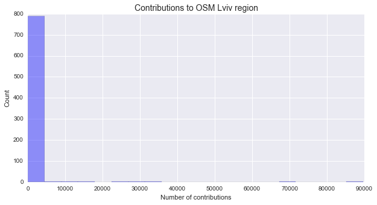

```python
#import pyplot library to make plots
import matplotlib.pyplot as plt
%matplotlib inline
import seaborn as sns

#create list of values we want to visualize
pipeline=[{'$group':{'_id':'$created.user','contributions':{'$sum':1}}},
          {'$project': {'contributions': '$contributions','_id':0}}]
values_list = []
for i in db.lviv.aggregate(pipeline):
    values_list.append(i.values()[0])

#construct the plot
plt.figure(figsize=(10,5))
plot = sns.distplot(values_list,bins = 20, kde = False, color = 'blue')
plt.title('Contributions to OSM Lviv region', fontsize = 14)
plt.xlabel('Number of contributions')
plt.ylabel('Count')
```

We see that the distribution is very scewed to the rigth and most contributors made less than 5000 contributions. Let's zoom in the distribution of the data, where the number of contributions is less than 5000 but more than 1.

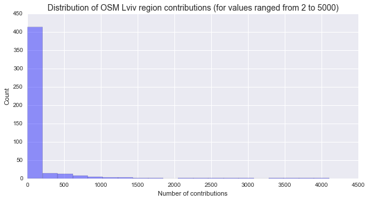

```python
#setting limit to the number of contributions and re-draw our histogram
pipeline=[{'$group':{'_id':'$created.user','contributions':{'$sum':1}}},
          {'$match':{'contributions':{'$lte':5000, '$gt':1}}},
          {'$project': {'contributions': '$contributions','_id':0 }}]

values_list_no_outliers = []
for i in db.lviv.aggregate(pipeline):
    values_list_no_outliers.append(i.values()[0])

#construct the plot
plt.figure(figsize=(10,5))
plot = sns.distplot(values_list_no_outliers,bins = 20, kde = False, color = 'blue')
plt.title('Distribution of OSM Lviv region contributions (for values ranged from 2 to 5000)', fontsize = 14)
plt.xlabel('Number of contributions')
plt.ylabel('Count')
```

As per this plot, the biggest part of the users (more than 50% of all users) made less than 200 contributions. This means that the OSM data is mostly edited by users manually, while the big numbers of contributions achieved by several users probably mean those users were perfoming automatic correction of OSM data.

#### Additional statistics for the dataset

Lviv is very old city and is famous for it's historical places. Let's see the top 5 historical spots we have in our Lviv collection

```python
print 'Lviv historical places:'
query = [{"$match":{"historic":{"$exists":1}}}, {"$group":{"_id":"$historic",
"count":{"$sum":1}}}, {"$sort":{"count":-1}}, {"$limit":5}]

for i in db.lviv.aggregate(query):
    print i
```

```
Lviv historical places:
{u'count': 108, u'_id': u'memorial'}
{u'count': 37, u'_id': u'monument'}
{u'count': 20, u'_id': u'tomb'}
{u'count': 6, u'_id': u'ruins'}
{u'count': 5, u'_id': u'wayside_cross'}
```

Let's also check up how many cafes, restaurants and bars we have in Lviv collection:

```python
print 'Lviv cafes, bars and restaurants:'
query = [{"$match":{'$or':[{'amenity':'restaurant'}, {'amenity':'cafe'},{'amenity':'bar'}]}},
         {"$group":{"_id":"$amenity","count":{"$sum":1}}}, {"$sort":{"count":-1}}]

for i in db.lviv.aggregate(query):
    print i
```

```
Lviv cafes, bars and restaurants:
{u'count': 339, u'_id': u'cafe'}
{u'count': 219, u'_id': u'restaurant'}
{u'count': 74, u'_id': u'bar'}
```

Lviv is famous for it's coffee, so let's see what coffee shops we have:

```python
print 'Lviv coffee shops:'
query = [{'$match':{'shop':'coffee'}},{'$project':{'name':'$name', '_id':0}}]

for i in db.lviv.aggregate(query):
    if i.values() !=[]:
        print i.values()[0]
```

```
Lviv coffee shops:
uk
Час на каву
Гармонія
Галка Маркет
Магазин Галка
Кава з собою
Кавовий Рай
Дівчата кава & Co
Львівський вандлер
Галка
```

### Ideas for improvement

I think, some sort of validation system to keep the entered data consistant, correct and complete is needed, that may include:

(1) Introducing stricter data format for certain fields, e.g.:

- non alphanumeric characters should not be allowed, while inserting the name of an amenity or a street name;
- streetnames, unless they start with digits, should be capitalized;
- phone numbers should contain at least 3-4 digits and should not contain letters etc;

Let's see some examples of invalid websites that we have in our Lviv collection:

```python
#see if we have the websites with all digits instead of url :
query = [{'$match':{'website':{'$regex':'^\d+$'}}},{'$project': {'website': '$website', '_id':0}}]
for a in db.lviv.aggregate(query):
    pprint.pprint(a)
```

```
{u'website': u'0687123023'}
{u'website': u'0679325049'}
```

Such problematic urls could have been easily avoided if the website field in map editor had pre-defined structure for the data entered (for the websites the proper format could be: protocol type - domain name - path).

Practically, I do see challenges about implementing stricter data format in OSM: different locations may have different standards for address format, phone number and so on. However, there are some general format patterns that could be defined in OSM map editor and would be acceptable regardless of the location, like : standard url structure, only digits for the phone numbers and many more.

The advantages of such an update are obvious : more consistant, clean and reliable infomation about objects on the map, which is certainly beneficial for OSM users

(2) Manual validation of the entered data (cross-checking): when a contributor is editing or creating a new point on the map, the system may automatically offer him to cross-check information about nearby objects created by other contributors. Such validation could be taken a step further if the system offers a map user to generate an automatic report when he finds that information about certain object on the map is incorrect, and that object information could be then suggested for edit to OSM contributors.

The challenge here would be to provide a motivation for contributors to check data entered by others, the solution might be introducing some competition mode among people contributing to OSM (badge system, ranking etc), so the contributors would be willing to cross check the data and earn additional points to their ranking or get a new badge.

The main advantage of this improvement would certainly be more correct and reliable data for OSM objects.

### Conclusion

In the course of this project we audited three fields in OSM Lviv region data, covering streetnames, housenumbers and postal codes.

We also did some validation of the data when it was needed, using external information as a 'golden standard' (validated postal codes against the list of the valid postcodes provided by Ukrainian National Postal Service), filled missing information (inserted street types where they were missing). We also cleaned the data programmatically, creating the cleaning strategy based on the results of our audit and validation.

Nevertheless, there are still many gaps in data for Lviv area in OpenStreetMap to fill in and many more data needs to be cleaned and validated.